# individual1

Alicia Hauglie

4/11/2019

**PART ONE: ACCIDENT DATA**

1. Are there some days of the week where more accidents happen than on others (use variable DAY_WEEK)?

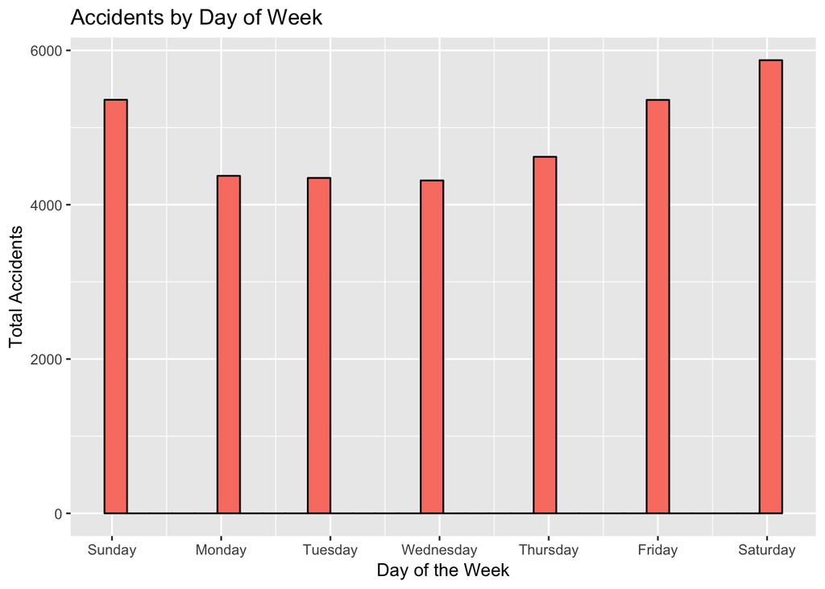

```r
library(ggplot2)
ggplot(data = acc, aes(x=DAY_WEEK)) + geom_histogram(color="black", fill="salmon") + ylab("Total Accidents") + xlab("Day of the Week")+ scale_x_continuous(breaks=c(1, 2, 3, 4, 5, 6, 7),labels=c("Sunday", "Monday", "Tuesday", "Wednesday", "Thursday", "Friday", "Saturday"))+ggtitle("Accidents by Day of Week")
```

Yes, most accidents seem to happen on the weekend (Friday-Sunday). This would make sense because more people are typically out and about on the weekends.

2. What time of the day do accidents happen (use variable HOUR)?

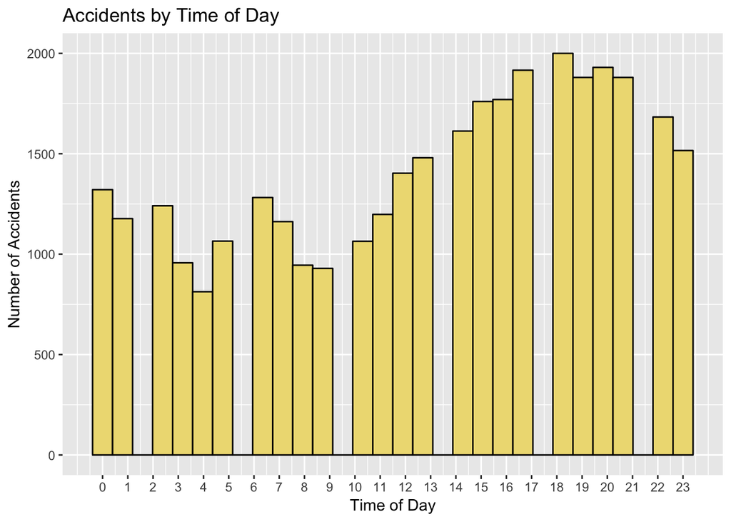

```r
acc$HOUR[acc$HOUR == 99] <- NA
ggplot(data = acc, aes(x=HOUR)) + geom_histogram(color="black", fill="lightgoldenrod2") + ylab("Number of Accidents") + xlab("Time of Day")+scale_x_continuous(breaks=c(0:23))+ggtitle("Accidents by Time of Day")
```

Based on the graph, we can see that most accidents happen between 4 pm and 10ish pm, which would make sense as this is the time when people are typically getting off of work, school, etc. and going home for the day. (This graph does not include the data with unknown hour of accident AKA 99)

3. What is the number of accidents with at least one drunk driver (use variable DRUNK_DR)?

```r
library(tidyverse)
drunkdriving1 <- acc %>% filter(DRUNK_DR > 0)
count(drunkdriving1)
```

```
## # A tibble: 1 x 1
##       n
##   <int>
## 1  8769
```

There are 8,769 accidents in this data in which there were at least 1 drunk drivers involved.

**PART TWO: CONNECTING DATA** 1. Load the person table. Identify drivers (PER_TYP == 1, see fars manual) and subset on them.

```r
drivers <- per %>% filter(PER_TYP == 1)
```

2. Join accident and driver table (work out which variable(s) to use)

```r
acc.drivers <-  inner_join(acc, drivers, by = "ST_CASE")
```

3. Tally the number of accidents by day of the week (DAY_WEEK), hour of the day (HOUR) and gender (SEX). Visualize the results!

```r
acc.drivers.clean <- acc.drivers %>% group_by(DAY_WEEK, HOUR.x, SEX)
tally(acc.drivers.clean)
```

```
## # A tibble: 579 x 4
## # Groups:   DAY_WEEK, HOUR.x [?]
##    DAY_WEEK HOUR.x   SEX     n
##       <int>  <int> <int> <int>
##  1        1      0     1   305
##  2        1      0     2    74
##  3        1      0     8     1
##  4        1      0     9    20
##  5        1      1     1   300
##  6        1      1     2    77
##  7        1      1     9    14
##  8        1      2     1   338
##  9        1      2     2   101
## 10        1      2     8     4
## # … with 569 more rows
```

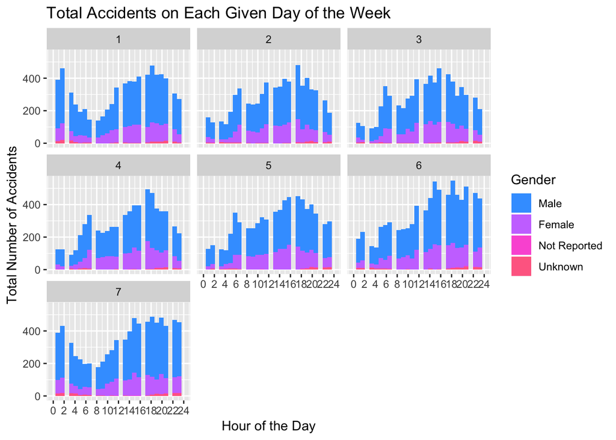

```r
hello <- ggplot(data = acc.drivers.clean, aes(x=HOUR.x, fill=factor(SEX))) + geom_histogram() + ylab("Total Number of Accidents") + xlab("Hour of the Day") + ggtitle("Total Accidents on Each Given Day of the Week")+scale_x_continuous(limits=c(0,24), breaks=c(0, 2, 4, 6, 8, 10,12, 14, 16,18, 20, 22, 24))+facet_wrap(~DAY_WEEK)
hello + scale_fill_discrete(name="Gender",
                         breaks=c("1", "2", "8", "9"),
                         labels=c("Male", "Female", "Not Reported", "Unknown"), h=c(250,360))
```

**PART THREE: CONNECTING DATA AND MAKING MAPS**

1. Now plot a choropleth map of accidents on a county level

```r
library(classdata)
library(tidyverse)
library("readxl")
CountyData <- read_excel("County Codes United States.xlsx")
```

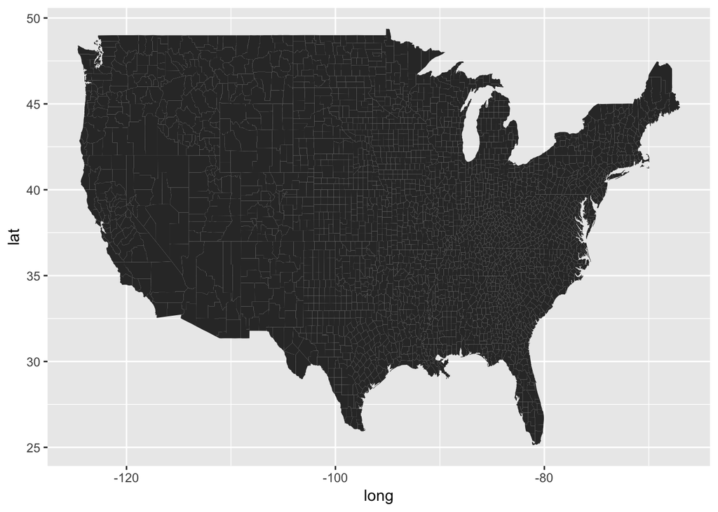

```r
county <- map_data("county")
ggplot(county, aes(x=long, y = lat)) + geom_polygon(aes(group=group))
```

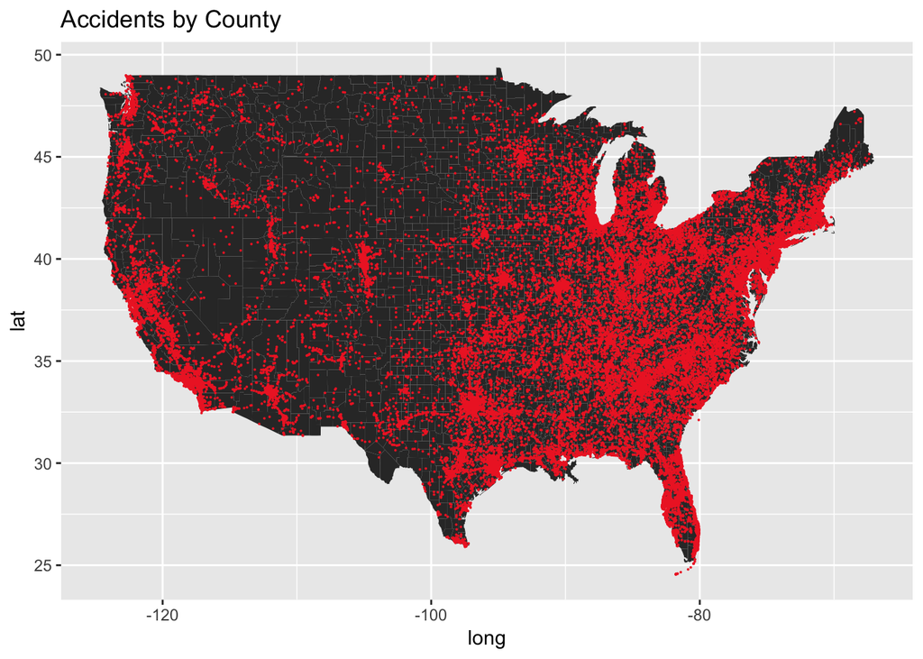

```r
acc.drivers.clean$`County Code` <- acc.drivers.clean$COUNTY.x
library(dplyr)
CountyData$`County Code` <- as.numeric(CountyData$`County Code`)
acc.drivers.clean <- acc.drivers.clean %>% select(`County Code`, LONGITUD, LATITUDE, DAY_WEEK, HOUR.x, SEX)
CountyData <- CountyData %>% select(`County Code`, `County Name`)
firstJoin <- inner_join(acc.drivers.clean, CountyData, by = "County Code")

ggplot(county, aes(x=long, y=lat))+geom_polygon(aes(group=group))+geom_point(aes(x=LONGITUD, y=LATITUDE), data=acc %>% filter(LONGITUD <0 & LONGITUD> -130), size=0.001, color="firebrick2")+ggtitle("Accidents by County")
```

Read the description for the STATE and COUNTY columns in the FARS manual. The state & county codes are Geographic Locator Codes (GLCs) from the General Services Administration’s (GSA) publication 2. Use readxl::read_xlsx to read in the GLCs

```r
GLC <- read_xlsx("FRPP GLC United States.xlsx")
```

```
## * … and 4 more
```

3. Visualize the number of accidents in each county using a choropleth map. To do this, you need to join the accident data, GLCs, and appropriate map data.

```r
glc.us<-readxl::read_xlsx("FRPP GLC United States.xlsx")
```

```
## * … and 4 more
```

```r
glc.terr<-readxl::read_xlsx("FRPP GLC US Territories.xlsx")
```

```
## * … and 4 more
```

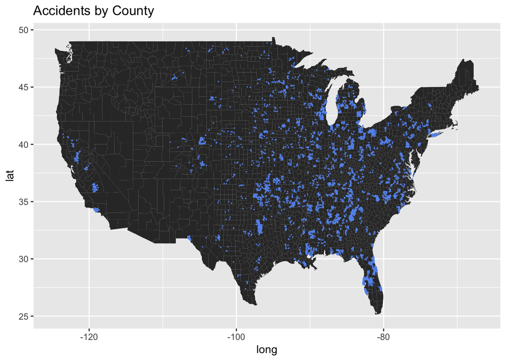

```r
colnames(glc.us)<-glc.us[1,]
glc.us<-glc.us[-1,]
colnames(glc.terr)<-glc.terr[1,]
glc.terr<-glc.terr[-1,]

acc <- mutate(acc, `County Code` = COUNTY)
acc$COUNTY <- as.numeric(acc$COUNTY)
acc$`County Code` <- as.numeric(acc$`County Code`)
joined.glc<- inner_join(glc.us, glc.terr, by = "County Code")
joined.glc$`County Code` <- as.numeric(joined.glc$`County Code`)
three_join <- inner_join(joined.glc, acc, by = "County Code")
filtered_three_join <- select(three_join, `County Code`, LATITUDE, LONGITUD, COUNTY, DAY, MONTH, YEAR, HOUR, ST_CASE)
filtered_three_join <- distinct(filtered_three_join, ST_CASE, .keep_all = TRUE)


ggplot(county, aes(x=long, y=lat))+geom_polygon(aes(group=group))+geom_point(aes(x=LONGITUD, y=LATITUDE), data=filtered_three_join %>% filter(LONGITUD <0 & LONGITUD> -130), size=0.01, color="cornflowerblue")+ggtitle("Accidents by County")
```

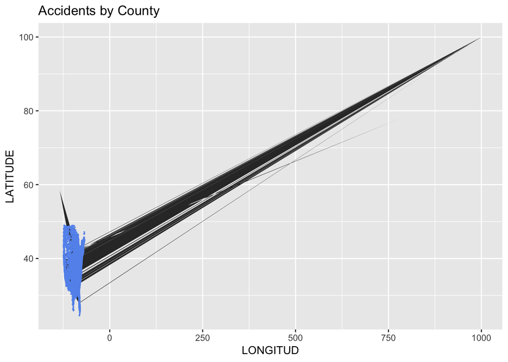

```r
#The above one looks more correct but
#I can't figure out how to get the joined three data on the map, it keeps showing no data for the west
ggplot(filtered_three_join, aes(x=LONGITUD, y=LATITUDE))+geom_polygon()+geom_point(aes(x=LONGITUD, y=LATITUDE), data=acc %>% filter(LONGITUD <0 & LONGITUD> -130), size=0.01, color="cornflowerblue")+ggtitle("Accidents by County")
```

4. Can you find seasonal trends in accident occurrences in different states? Is summer or winter more dangerous? Why?

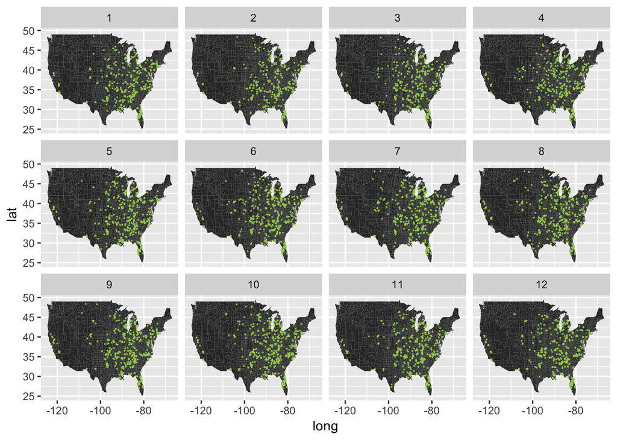

```r
ggplot(county, aes(x=long, y=lat))+geom_polygon(aes(group=group))+geom_point(aes(x=LONGITUD, y=LATITUDE), data=filtered_three_join  %>% filter(LONGITUD <0 & LONGITUD > -130), size=0.01, color="darkolivegreen3")+facet_wrap(~MONTH)
```

# I had it showing more points before but then I messed it up and can’t get it back LOL great